# Randomization inference

David Linnard Wheeler

6/14/2021

### Imagine that we want to determine if some groups are *different* from each other.

Let’s load some data to demonstrate:

```r
# The top of the data table/frame
head(d)
```

```
##    bid auction_type
## 1:   5            1
## 2:   5            1
## 3:  20            0
## 4:   0            1
## 5:  20            1
## 6:   0            1
```

Next, let’s formulate a clear question and testable hypothesis:

**Question**: Is there a difference in bids between different auction types?

**Sharp $H_0$**: $\tau_i = Y_i(0) - Y_i(1) = 0$ for each subject/unit.

- Note that this is a **much** stronger assertion than the typical, difference in means, hypothesis we generally pose.
- Also, note that randomization inference is flexible- we can test many types of hypotheses.

#### Before we do anything fancy let’s just see if there is *a* difference between the two treatments

```r
# Group mus and sigmas by auction type
knitr::kable(d[ , .(mu_hat=mean(bid),
      sigma_hat=sqrt(var(bid))),
   by = auction_type ],
   format = "html",
   table.attr = "style='width:30%;'")
```

| auction_type | mu_hat | sigma_hat |
| --- | --- | --- |
| 1 | 16.61765 | 15.40172 |
| 0 | 28.82353 | 19.98101 |

Numerically, the groups *appear* different. Let’s look closer:

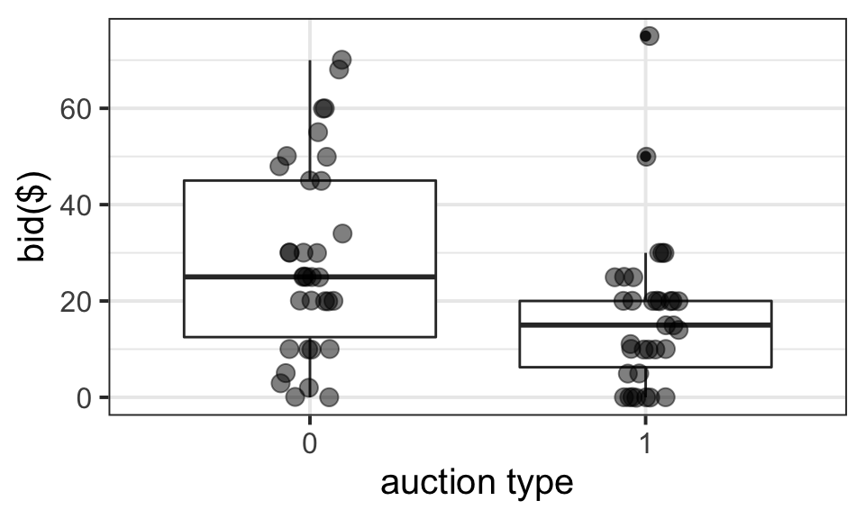

```r
d %>%
ggplot(aes(x=auction_type, y=bid,
           group=auction_type)) +
geom_boxplot() +
  geom_jitter(size=5, pch=20, alpha=1/2,
              position=position_jitter(w=0.1, h=0.1))+
  theme_bw(base_size = 15) +
  labs(x="auction type", y="bid($)")
```

#### So, are they *really* different

```r
# # 1st solution
# ate <- d[ , mean(bid), keyby = .(auction_type)][ , diff(V1)]
# ate
# # 2nd solution
# TCmeans <- d[ , .(mu = mean(bid)), keyby=.(auction_type)]
# ate <- TCmeans[ , diff(mu)]
# ate
# 3rd solution
ts <- mean(d$bid[d$auction_type == 1]) - mean(d$bid[d$auction_type == 0])
ts
```

```
## [1] -12.20588
```

##### One way to test for a difference-in-means with a t-test:

```r
# t-test 1
#d[ , t.test(bid ~ auction_type)]
# t-test 2
t <- t.test(bid ~ auction_type, data=d)

# t-test statistic
# t$statistic[[1]]

# t-test statistic
# t$conf.int[1:2]
```

This method is OK if you satisfy the requisite assumptions and sometimes even if you do not…

But these assumptions can be restrictive.

This is where randomization inference can come to the rescue.

##### Another solution is to use randomization inference (RI).

There are many ways to introduce RI. Most are intuitive.

First, let’s go back in time to just before treatment assignment.

```r
# 1 solution
ts <- mean(d$bid[d$auction_type == 1]) - mean(d$bid[d$auction_type == 0])
# 2 Solution
tslm <- lm(bid ~ auction_type, data=d)
# all together now
knitr::kable(data.table(method = c("ByHand","LinearModel"),
           estimate = c(ts, tslm$coefficients[[2]])),
   format = "html",
   table.attr = "style='width:30%;'")
```

| method | estimate |
| --- | --- |
| ByHand | -12.20588 |
| LinearModel | -12.20588 |

- Null distribution
  - This is the *meat and potatoes* of RI.
  - With other methods, like a t-test, we compute our test statistic,$t$, find it under the sampling distribution of the statistic (a $t$ distribution) and use the probability of observing our $t$ or one more extreme under the null as evidence against our $H_0$.
  - With RI, we use a simpler approach.
    - First, we assume the sharp null ($\tau_i = Y_i(0) - Y_i(1) = 0$ for each subject/unit) is true.
    - If the sharp null is true than then treatment has no effect on each unit. Thus, we can shuffle (ahem, *permute*) the treatment vector, calculate our test statistic after each permutation, and repeat *many* times. This procedure yields the sampling distribution of our test-statistic. This DIY null distribution describes all of the possible test-statistics that could have arisen with *our* data.
    - Next we just find our original test-statistic (the one we calculated before the permutations, here its -12.2058824).
- This is how this works:

```r
# example 1
# Null distribution
null_dist1 <- NA
# For each randomization, r, from 1 to 10000
for(r in 1:10000) {
  # populate this empty vector, ri_distribution, with ates after each shuffle
  null_dist1[r] <- d[ , .(group_mean = mean(bid)),
    keyby = .(sample(auction_type))][ , diff(group_mean)]
}
```

```r
# example 2
# Randomization inference
# Vector  of NAs to replace with estimates under randomization
null_dist2 <- rep(NA, 10000)

# For each test statistic, ATE, from 1 to 10,000
for(a in 1:10000) {
  # Assign to treatment, a random vector of 0s and 1s.
  # Let the number of 0s and 1s be equal to the number of winners (1) and non-winners (0)
  treatment <- sample(c(rep(0, sum(d$auction_type == 0)),
                        rep(1, sum(d$auction_type == 1))),
                  replace = TRUE)
  # Assign ate to the difference in mean views for winners and non-winners
  null_dist2[a] <- d[treatment==1, .(mean(bid))] - d[treatment==0, .(mean(bid))]
}
```

```r
# Example 3
# Build vector of randomized treatment assignments
sim.study <- function() {
  # data table with two columns
                      # vector of RANDOMIZED treatment assignments
  d.sim <- data.table(auction_type = sample(c(rep(0,length(d$auction_type)/2),
                                          rep(1,length(d$auction_type)/2))),
                      # vector of ORIGINAL response/label/dependent variable
                      bid = d$bid)
  # Group means
  group_means <- d.sim[ , .(mean_bids = mean(bid)),
                keyby = auction_type]# [, diff(group_mean)]
  # test statistics
  tss <- group_means[auction_type == 1]$mean_bids - group_means[auction_type == 0]$mean_bids
  # Vector of ATEs
  return(tss)

}

# Run simulations
null_dist3 <- t(replicate(10000, sim.study()))
```

Let’s visualize our DIY null distribution:

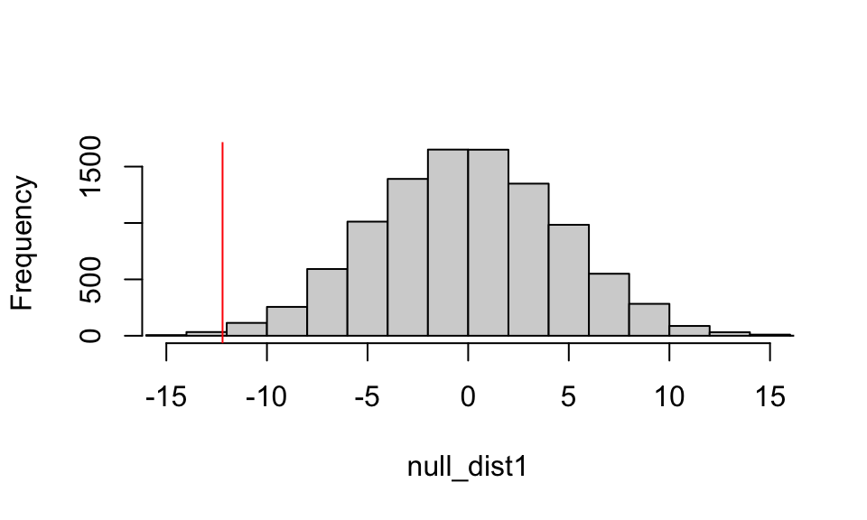

```r
#par(mfrow=c(3,1))
# All ATEs
hist(null_dist1,
     xlim=c(-15,15), main=" ")
# Our original ATE
abline(v=ts, col="red")
```

```r
# # All ATEs
# hist(as.numeric(null_dist2),
#      xlim=c(-15,15), main=" ")
# # Our original ATE
# abline(v=ts, col="red")
#
# # All ATEs
# hist(as.numeric(null_dist3[1,]),
#      xlim=c(-15,15), main=" ")
# # Our original ATE
# abline(v=ts, col="red")
```

#### How do we interpret this?

- This is where the measure of extremeness comes in to play.
  - In general we have two choices:
    1. Interpret large OR small simulated test statistics as *directional* evidence against the null
    2. Interpret large AND small simulated test statistics as *categorical* evidence against the null

To do this, we can just count the number of simulated test statistics that are larger in absolute value than our actual test statistic.

```r
# number of larger ates
larger_ts1 <- sum(null_dist1 > abs(ts))
larger_ts1
```

```
## [1] 37
```

```r
# number of larger ates
larger_ts2 <- sum(abs(null_dist1) > abs(ts))
larger_ts2
```

```
## [1] 70
```

Further we can calculate conficence intervals

```r
# CI
ri.CI <- quantile(null_dist1,
                  probs = c(0.025, 0.975))
# Centered about the ate
ri.CI <- ri.CI + ts

ri.CI[[1]]; ri.CI[[2]]
```

```
## [1] -21.35294
```

```
## [1] -3.176471
```

And p-values

```r
# 1-tailed P-value
p_value_1tail <-  sum(null_dist1 >= abs(ts))/10000 # mean(ri_distribution >= abs(ate))

# 2-tailed P-value
p_value_2tailed <- sum(abs(null_dist1) >= abs(ts))/10000 # mean(abs(ri_distribution) >= abs(ate))

# Compare
knitr::kable(data.table("Test" = c("T.test","RI.1tail", "RI.2tailed"),
            "statistic" = c(t$statistic[[1]], ts, ts),
           "confidence_interval_UB" = c(t$conf.int[1], ri.CI[[2]], ri.CI[[2]]),
            "confidence_interval_UB" = c(t$conf.int[2], ri.CI[[1]], ri.CI[[1]]),
            "p-values" = c(p_value_1tail, p_value_2tailed, t$p.value)),
   format = "html",
   table.attr = "style='width:70%;'")
```

| Test | statistic | confidence_interval_UB | confidence_interval_UB | p-values |
| --- | --- | --- | --- | --- |
| T.test | 2.821144 | 3.557141 | 20.85462 | 0.0038000 |
| RI.1tail | -12.205882 | -3.176471 | -21.35294 | 0.0073000 |
| RI.2tailed | -12.205882 | -3.176471 | -21.35294 | 0.0064208 |

Does this make sense?

What did we learn?

Three benefits of RI: - Its flexible. - Its agnostic to many assumptions. - It is exact because the set of all possible random assignments fully describe the sampling distribution under the null hypothesis. Many other methods derive the shape of sampling distributions by approximation.

#### Resources:

- [Fisher’s Randomization Inference](https://www.mattblackwell.org/files/teaching/s05-fisher.pdf)
- [R package](http://alexandercoppock.com/ri2/articles/ri2_vignette.html) [Field experiments: design, analysis, and interpretation](https://www.amazon.com/Field-Experiments-Design-Analysis-Interpretation/dp/0393979954)